# Supervised Learning - Regression Trees and Bagging

Jan-Philipp Kolb

03 Juni, 2019

# [Tree-Based Models](https://www.statmethods.net/advstats/cart.html)

- Trees are good for interpretation because they are simple
- Tree based methods involve stratifying or segmenting the predictor space into a number of simple regions. ([**Hastie and Tibshirani**](https://lagunita.stanford.edu/c4x/HumanitiesScience/StatLearning/asset/trees.pdf))

### But:

- These methods do not deliver the best results concerning prediction accuracy.

# The Idea

- There are many methodologies for constructing regression trees but one of the oldest is the [**classification and regression tree**](https://machinelearningmastery.com/classification-and-regression-trees-for-machine-learning/) (CART) approach by Breiman et al. (1984).
- Basic [**regression trees partition a data set into smaller subgroups**](https://towardsdatascience.com/the-complete-guide-to-decision-trees-28a4e3c7be14) and then fit a simple constant for each observation in the subgroup.
- The partitioning is achieved by successive [**binary partitions**](https://en.wikipedia.org/wiki/Binary_space_partitioning) (aka [recursive partitioning](https://en.wikipedia.org/wiki/Recursive_partitioning)) based on the different predictors.
- The constant to predict is based on the average response values for all observations that fall in that subgroup.

# Explanation: [**decision tree**](https://en.wikipedia.org/wiki/Decision_tree)

Decision trees model data as a “tree” of hierarchical branches. They make branches until they reach “leaves” that represent predictions.

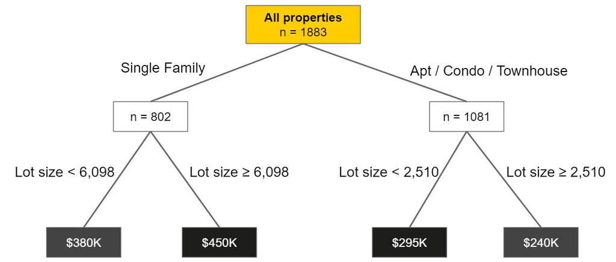

[Decission tree on ElitedataScience](https://elitedatascience.com/algorithm-selection)

# Example decission trees

Due to their branching structure, decision trees can easily model nonlinear relationships.

### Example

- For single family homes (larger lots) higher prices,
- and for apartments (smaller lots), also higher prices (because here it’s a proxy for urban / rural).

This reversal of correlation is difficult for linear models to capture unless you explicitly add an interaction term

- Decision trees can capture this relationship naturally.

# Model foundations

- This simple example can be generalized
- We have a continuous response variable $Y$ and two inputs $X_1$ and $X_2$.
- The recursive partitioning results in three regions ($R_1$,$R_2$,$R_3$) where the model predicts $Y$ with a constant $c_m$ for region $R_m$:

$$\hat{f} (X) = \sum\limits_{m=1}^3c_mI(X_1,X_2)\in R_m$$

# How to grow a regression tree - deciding on splits

- It is important to realize the partitioning of variables are done in a top-down approach.
- A partition performed earlier in the tree will not change based on later partitions.

### How are these partions made?

- The model begins with the entire data set, $S$, and searches every distinct value of every input variable to find the predictor and split value that partitions the data into two regions ($R_1$ and $R_2$) such that the overall sums of squares error are minimized:

$$\text{minimize}\{SSE=\sum\limits_{i\in R_1}(y_i - c_1)^2 + \sum\limits_{i\in R_2} (y_i - c_2)^2 \}$$

# The best split

- Having found the best split, we partition the data into the two resulting regions and repeat the splitting process on each of the two regions.
- This process is continued until some stopping criterion is reached.
- We typically get a very deep, complex tree that may produce good predictions on the training set, but is likely to [**overfit**](https://www.researchgate.net/post/What_is_over_fitting_in_decision_tree) the data, leading to poor performance on unseen data.

# Regression Trees - preparation

- The following slides are based on the UC Business Analytics R Programming Guide on [**regression trees**](http://uc-r.github.io/regression_trees)

```r
library(rsample)     # data splitting
library(dplyr)       # data wrangling
library(rpart)       # performing regression trees
library(rpart.plot)  # plotting regression trees
library(ipred)       # bagging
library(caret)       # bagging
```

# The Ames Housing data

- Again we use the Ames dataset and split it in a test and training dataset

```r
set.seed(123)
ames_data <- AmesHousing::make_ames()
ames_split <- initial_split(ames_data,prop = .7)
ames_train <- training(ames_split)
ames_test  <- testing(ames_split)
```

# Pruning

- We create three decision trees based on three different samples of the data.
- The first few partitions are fairly similar at the top of each tree; - they tend to differ closer to the terminal nodes.
- These deeper nodes tend to overfit to specific attributes of the sample data;
- Slightly different samples will result in highly variable estimate/ predicted values in the terminal nodes.
- By [**pruning**](https://dzone.com/articles/decision-trees-and-pruning-in-r) these lower level decision nodes, we can introduce a little bit of bias in our model that help to stabilize predictions and will tend to generalize better to new, unseen data.

# Three decision trees based on three samples.

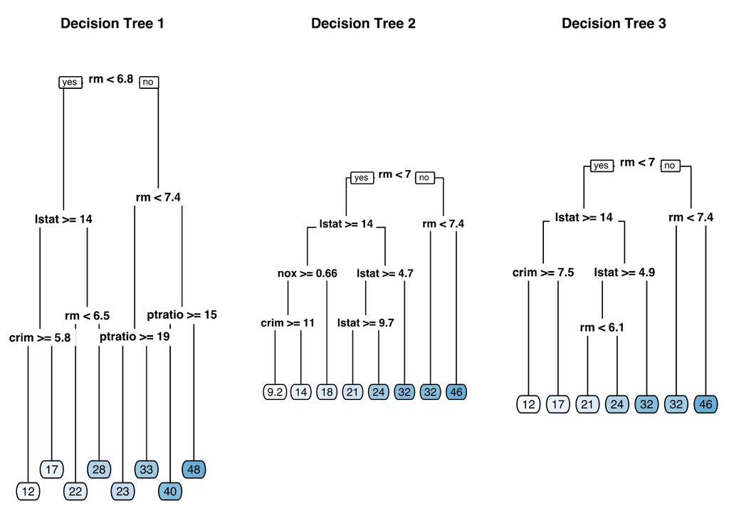

# Cost complexity criterion

- There is often a balance to be achieved in the depth and complexity of the tree to optimize predictive performance on some unseen data.
- To find this balance, we grow a very large tree as showed and then prune it back to find an optimal subtree.
- We find this subtree by using a cost complexity parameter ($\alpha$) that penalizes our objective function for the number of terminal nodes of the tree (T).

$$\text{minimize}\{SSE + \alpha|T|\}$$

# The complexity value $\alpha$

- For a given value of $\alpha$, we find the smallest pruned tree that has the lowest penalized error.
- $\rightarrow$ A close association to the lasso $L_1$ norm penalty.
- Smaller penalties tend to produce more complex models, which result in larger trees.
- Larger penalties result in much smaller trees.
- As a tree grows larger, the reduction in the SSE must be greater than the cost complexity penalty.
- We evaluate multiple models across a spectrum of $\alpha$ and use cross-validation to identify the optimal $\alpha$ and the optimal subtree.

# Fit a regression tree using `rpart`

- The fitting process and the visual output of regression trees and classification trees are very similar.
- Both use the formula method for expressing the model (similar to `lm`).
- When fitting a regression tree, we need to set `method = "anova"`.
- By default, `rpart` will make an intelligent guess based on the data type of the response column
- But it’s recommened to explictly set the method for reproducibility reasons (auto-guesser may change in future).

```r
m1 <- rpart(formula = Sale_Price ~ .,data = ames_train,
            method  = "anova")
```

# the `m1` output.

[figure not shown]

```r
m1
```

```
## n= 2051
##
## node), split, n, deviance, yval
##       * denotes terminal node
##
##  1) root 2051 1.273987e+13 180775.50
##    2) Overall_Qual=Very_Poor,Poor,Fair,Below_Average,Average,Above_Average,Good 1703 4.032269e+12 156431.40
##      4) Neighborhood=North_Ames,Old_Town,Edwards,Sawyer,Mitchell,Brookside,Iowa_DOT_and_Rail_Road,South_and_West_of_Iowa_State_University,Meadow_Village,Briardale,Northpark_Villa,Blueste 1015 1.360332e+12 131803.50
##        8) First_Flr_SF< 1048.5 611 4.924281e+11 118301.50
##         16) Overall_Qual=Very_Poor,Poor,Fair,Below_Average 152 1.053743e+11  91652.57 *
##         17) Overall_Qual=Average,Above_Average,Good 459 2.433622e+11 127126.40 *
##        9) First_Flr_SF>=1048.5 404 5.880574e+11 152223.50
##         18) Gr_Liv_Area< 2007.5 359 2.957141e+11 145749.50 *
##         19) Gr_Liv_Area>=2007.5 45 1.572566e+11 203871.90 *
##      5) Neighborhood=College_Creek,Somerset,Northridge_Heights,Gilbert,Northwest_Ames,Sawyer_West,Crawford,Timberland,Northridge,Stone_Brook,Clear_Creek,Bloomington_Heights,Veenker,Green_Hills 688 1.148069e+12 192764.70
##       10) Gr_Liv_Area< 1725.5 482 5.162415e+11 178531.00
##         20) Total_Bsmt_SF< 1331 352 2.315412e+11 167759.00 *
##         21) Total_Bsmt_SF>=1331 130 1.332603e+11 207698.30 *
##       11) Gr_Liv_Area>=1725.5 206 3.056877e+11 226068.80 *
##    3) Overall_Qual=Very_Good,Excellent,Very_Excellent 348 2.759339e+12 299907.90
##      6) Overall_Qual=Very_Good 249 9.159879e+11 268089.10
##       12) Gr_Liv_Area< 1592.5 78 1.339905e+11 220448.90 *
##       13) Gr_Liv_Area>=1592.5 171 5.242201e+11 289819.70 *
##      7) Overall_Qual=Excellent,Very_Excellent 99 9.571896e+11 379937.20
##       14) Gr_Liv_Area< 1947 42 7.265064e+10 325865.10 *
##       15) Gr_Liv_Area>=1947 57 6.712559e+11 419779.80
##         30) Neighborhood=Old_Town,Edwards,Timberland 7 8.073100e+10 295300.00 *
##         31) Neighborhood=College_Creek,Somerset,Northridge_Heights,Northridge,Stone_Brook 50 4.668730e+11 437207.00
##           62) Total_Bsmt_SF< 2168.5 40 1.923959e+11 408996.90 *
##           63) Total_Bsmt_SF>=2168.5 10 1.153154e+11 550047.30 *
```

# Steps of the splits (m1) - explained

- E.g., we start with 2051 observations at the root node (very beginning) and the first variable we split on (that optimizes a reduction in SSE) is `Overall_Qual`.
- We see that at the first node all observations with

```
Overall_Qual=Very_Poor,Poor,Fair,Below_Average,Average,
Above_Average,Good
```

go to the 2nd branch.

# The 3rd branch

`Overall_Qual=Very_Good,Excellent,Very_Excellent`

### Visualization with `rpart.plot`

# The package `rpart.plot`

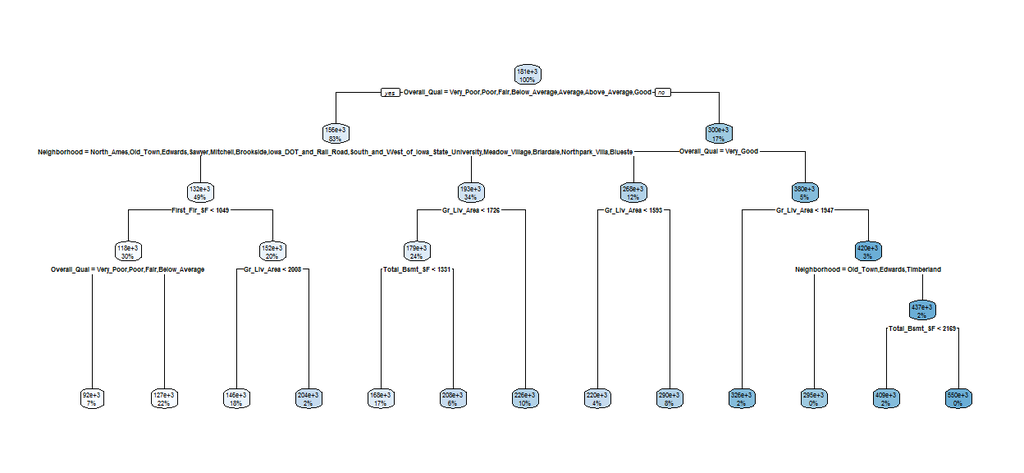

```r
rpart.plot(m1)
```

# Behind the scenes

There are 80 variables in `ames_train`. So what happened?

- `rpart` is automatically applying a range of cost complexity $\alpha$ values to prune the tree.
- To compare the error for each $\alpha$ value, `rpart` performs a 10-fold cross validation so that the error associated with a $\alpha$ value is computed on the hold-out validation data.

# The `plotcp`

- Lower x-axis - cost complexity - alpha

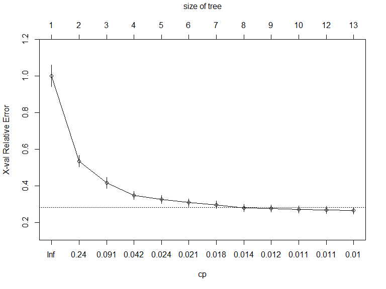

```r
plotcp(m1)
```

# The 1-SE rule - how many terminal nodes

# Generate a full tree

- After 12 terminal nodes, we see diminishing returns in error reduction as the tree grows deeper.
- Thus, we can signifcantly prune our tree and still achieve minimal expected error.

```r
m2 <- rpart(formula = Sale_Price ~ .,data=ames_train,
    method  = "anova",control = list(cp = 0, xval = 10))
```

- `control` - a list of options that control details of the rpart algorithm.
- `cp` - complexity parameter. Any split that does not decrease the overall lack of fit by a factor of cp is not attempted. For instance, with anova splitting, this means that the overall R-squared must increase by cp at each step (Pruning).
- `xval` number of cross-validations.

# Plot the result

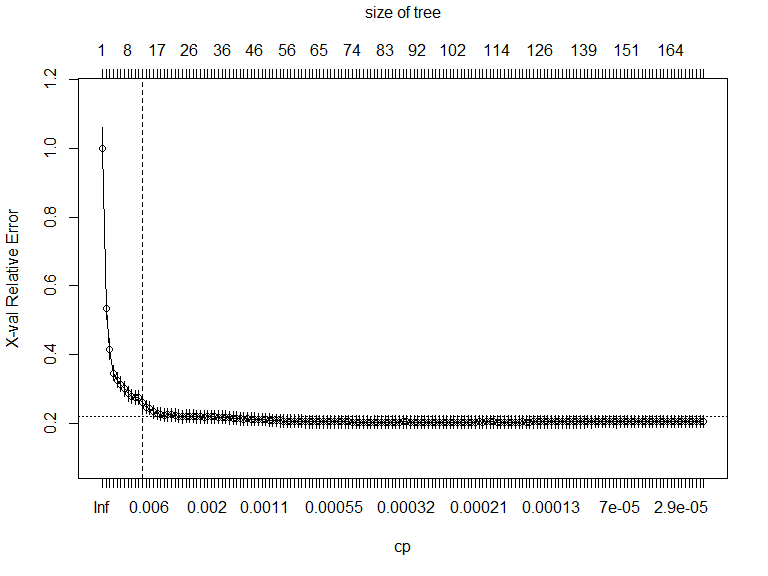

```r
plotcp(m2);abline(v = 12, lty = "dashed")
```

# Automated tuning by default

# The output `cptable`

```r
m1$cptable
```

```
##            CP nsplit rel error    xerror       xstd
## 1  0.46690132      0 1.0000000 1.0009222 0.05855161
## 2  0.11961409      1 0.5330987 0.5347929 0.03116217
## 3  0.06955813      2 0.4134846 0.4151417 0.03058554
## 4  0.02559992      3 0.3439265 0.3461258 0.02207839
## 5  0.02196620      4 0.3183265 0.3242197 0.02182111
## 6  0.02023390      5 0.2963603 0.3074877 0.02129292
## 7  0.01674138      6 0.2761264 0.2963372 0.02106996
## 8  0.01188709      7 0.2593850 0.2795199 0.01903482
## 9  0.01127889      8 0.2474980 0.2762666 0.01936472
## 10 0.01109955      9 0.2362191 0.2699895 0.01902217
## 11 0.01060346     11 0.2140200 0.2672133 0.01883219
## 12 0.01000000     12 0.2034165 0.2635207 0.01881691
```

# Tuning

In addition to the cost complexity ($\alpha$) parameter, it is also common to tune:

### `minsplit`:

- The minimum number of data points required to attempt a split before it is forced to create a terminal node. The default is 20. Making this smaller allows for terminal nodes that may contain only a handful of observations to create the predicted value.

### `maxdepth`:

- The maximum number of internal nodes between the root node and the terminal nodes. The default is 30, which is quite liberal and allows for fairly large trees to be built.

# Special control argument

- `rpart` uses a special control argument where we provide a list of hyperparameter values.
- E.g., if we want a model with `minsplit = 10` and `maxdepth = 12`, we could execute the following:

```r
m3 <- rpart(formula = Sale_Price ~ .,data = ames_train,
    method  = "anova", control = list(minsplit = 10,
                          maxdepth = 12, xval = 10)
)
```

# The output `cptable` of model 3

```r
m3$cptable
```

```
##            CP nsplit rel error    xerror       xstd
## 1  0.46690132      0 1.0000000 1.0004448 0.05850012
## 2  0.11961409      1 0.5330987 0.5343156 0.03093134
## 3  0.06955813      2 0.4134846 0.4148699 0.03035832
## 4  0.02559992      3 0.3439265 0.3455539 0.02190359
## 5  0.02196620      4 0.3183265 0.3259151 0.02168056
## 6  0.02023390      5 0.2963603 0.3062045 0.02114604
## 7  0.01674138      6 0.2761264 0.3061135 0.02176061
## 8  0.01188709      7 0.2593850 0.2917534 0.02058535
## 9  0.01127889      8 0.2474980 0.2872380 0.02441006
## 10 0.01109955      9 0.2362191 0.2850234 0.02440721
## 11 0.01060346     11 0.2140200 0.2829790 0.02334151
## 12 0.01000000     12 0.2034165 0.2735069 0.02260957
```

# Grid search

- We can avoid it to manually assess multiple models, by performing a grid search to automatically search across a range of differently tuned models to identify the optimal hyerparameter setting.
- To perform a grid search we first create our hyperparameter grid.

```r
hyper_grid <- expand.grid(
  minsplit = seq(5, 20, 1),
  maxdepth = seq(8, 15, 1)
)
```

- The result are 128 combinations - 128 different models.

```r
head(hyper_grid)
```

```
##   minsplit maxdepth
## 1        5        8
## 2        6        8
## 3        7        8
## 4        8        8
## 5        9        8
## 6       10        8
```

```r
nrow(hyper_grid)
```

```
## [1] 128
```